# Early childhood factors and health and Human capital

The paper surveys the literature on how early childhood factors affect health and human capital developments.

Author

Affiliation

Lakshmi K. Raut

Visiting Fellow, University of Chicago

Published

October 26, 2023

Abstract

In this paper I survey the microbiology, psychology and Economics literatures on human development, focusing on the role of early childhood factors. The paper focuses on two aspects of Human developments. First, it focuses on the process of aging such as development of chronic diseases, disability and mortality. Second focus is on the process of human capital developments and its effects on labor market outcomes, earnings inequality and social mobility. Human capital developments include cognitive and non-cognitive skill formations such as social, motivational and self-control skills. I draw from the microbiology literature on developmental programming and the roles played by genetic and epigenetic factors, which is also known as the nature – nurture controversy, and from the theory of mind from the psychology literature. I also present some of the empirical findings from my own research and joint research with Professor James Heckman (the Nobel Laureate in Economics) using the HRS (Health and Retirement Surveys) and the NLSY (National Longitudinal Surveys) 1979 datasets. Both are US datasets. Similar datasets are not available for India. I will also interact with the audience about possible research ideas in the context of India.

# 1 Introduction

The growing income inequality has been a big concern for economists and policy makers around the world. Many factors are responsible for the observed burgeoning income inequality, such as capital outflow, relocation of jobs, declining labor union, i.e., declining bargaining power of the labor, poor regulation of financial institutions, corruption, and all-encompassing globalization (Piketty 2014; Stiglitz 2015; Bourguignon 2015). In most economies, incomes of the bottom 99 percent come mainly from earnings and much of the inequality in earnings results from the inequality of skill formations (Autor 2014).

A growing consensus reached among educators, media writers (see for instance, Traub 2000), researchers in sociology, psychology and education [for instance, see (Barnett 1995; Entwisle 1995; McCormick 1989; Reynolds et al. 2001; Reynolds, Ou, and Temple 2018; Schweinhart, Barnes, and Weikart 1993) and researchers in economics, (see for instance, Currie 2001, 2011; Currie and Almond 2011; Duncan, Ziol-Guest, and Kalil 2010; Heckman 2000; Heckman et al. 2010; Heckman and Raut 2013, 2016; Keane and Wolpin 1997; Garcia et al. 2016; Raut 2018, 2003; Maluccio et al. 2009) is that the children of poor SES are not prepared for college because they were not prepared for school to begin with. The summarized literature below in psychology, economics and the recently emerging genetics and epigenetics of health, cognitive and noncognitive developments of children show that the most effective intervention for the children of poor SES should be introduced at the preschool stage so that these children are prepared for schools and colleges and better health.

Children of poor SES perform poorly in skill acquisition and in the labor market. Many children of poor SES do not complete high school and many of them perform poorly in schools. Gaps in test scores between rich and poor children are substantial, and unequal schooling does little to widen this gap. In spite of its positive effects on test scores and earnings, the effects of improved school quality on school dropout rates is marginal.

# 2 Starting from the start

Figure 1: Life-cycle of a female starting from conception

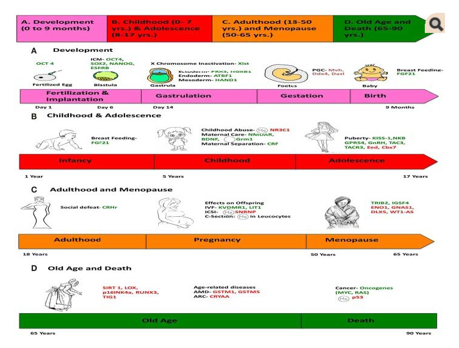

# 3 Human Capital Accumulation

Most earlier research in the last century focused on cognitive skills as the main determinant of socioeconomic behaviors, school performances and labor market outcomes. One line of influential but controversial research argues that poor parents have poor cognitive abilities and that is why they are poor; children of poor SES inherit poor cognitive abilities from their parents; thus very little can be done to improve the cognitive skills of the disadvantaged children, and hence their school performance and labor market outcomes, see Herrnstein and Murray (1994) and other references in Plomin and Deary (2015). This view has been refuted using more appropriate data and statistical techniques. More recent research in neuroscience, psychology, economics and experimental game theory emphasize that it is the interplay of emotions and cognition that determine most social and economic behaviors (Camerer, Loewenstein, and Prelec 2005; Kahneman 2013; Winter 2014).

In psychology literature, especially in the work of Bowlby (Bowlby 1982), it has been argued that affect (emotion) dysregulation which begins to form immediately after birth, especially during the first two years of age, from low quality interaction of the primary care-taker (generally the mother) with the baby can have long lasting effects on emotional development of the child in later ages. NETWORK (2004) carried a longitudinal study and found evidence for such affect dysregulation mechanisms. The emotional dysregulation also conditions cognitive developments of children. More recent neurological research on this phenomena confirms this, see for instance, A. N. Schore (2005).

Using the fMRI images of brain areas a number of neurological studies found that poverty has significant negative effects on development a child’s certain areas of brain that are responsible for cognition, executive functions and emotions. For instance, a large scale neurological study by Kimberly G. Noble et al. (2015) found that family income significantly affects children’s brain size, particularly in the surface area of the cerebral cortex that does most of the cognitive processing. See also their earlier study, Kimberly G. Noble et al. (2012) and the commentary in Balter (2015). Hair et al. (2015) conducted a large longitudinal neurological studies on children starting at an early age, and followed them up into their school years. They measured their scores on cognitive and academic achievements, and development of brain tissue, including gray matter of the total brain, frontal lobe, temporal lobe, and hippocampus. They found significant negative effects of poverty on developments of these areas and on their academic achievements.

It is the interplay of personality, emotion and cognition that determines most socioeconomic behaviors. Recent research in psychology, neurobiology, experimental game theory, and economics emphasize this. A branch of the psychology literature argues and empirically validates that the emotional intelligence is an important factor in socioeconomic decisions and behaviors—not the cognitive intelligence alone. Many definitions and measurements for emotional intelligence exit in the literature, however, the concept more relevant to our context is quoted from Mayer, Salovey, and Caruso (2004), “{[Emotional Intelligence is the] capacity to reason about emotions, and of emotions to enhance thinking. It includes the abilities to accurately perceive emotions, to access and generate emotions so as to assist thought, to understand emotions and emotional knowledge, and to reflectively regulate emotions so as to promote emotional and intellectual growth”. (Bar-On 2000; Goleman 2009) use somewhat broader definitions by including other personality traits in their definitions. It has been found that measures based on all these different definitions are highly correlated with each other and each explains strongly many socioeconomic behaviors independent of cognitive skills, (see Chakrabarti and Chatterjea (2017) for some of these results in psychology and for a synthesis of various definitions, and (Raut 2003; Heckman and Raut 2016; Almlund et al. 2011) for significant positive effects of non-cognitive skills on labor market earnings, independent of the effects of cognitive skills).

Group outcomes are generally more efficient than what individuals could do by themselves. Group activities to attain some common goal, however, require each member of the group to perform constant mind reading of the other members and evaluate how others may react to one’s action. The mechanism by which one reads other’s mind in a conflicting or cooperative situation is known in the psychology literature as theory of mind, a term introduced by Premack and Woodruff (1978). Doherty (2008) describes various mechanisms for the theory of mind. One who has better emotional intelligence and a better theory of mind can be more effective in a group, and can become the leader of the group. A group can have a higher level of group emotional intelligence and cognitive intelligence than another group, and can be more efficient and more productive as a result for many activities, Woolley et al. (2010). In experimental game theory such non-cognitive skills—emotional intelligence and theory of mind—play important role (Camerer, Loewenstein, and Prelec 2005; Kahneman 2013; Winter 2014). The recent economics literature shows that non-cognitive skills such as socialization and motivation are also important for positive labor market outcomes (Deming 2017; Heckman and Raut 2016; Raut 2003; Maluccio et al. 2009).

Where are these emotional intelligence or non-cognitive skills and the cognitive skills produced? For the effect of early childhood experiences, especially mother-child interactions, on the development of the theory of mind of the child, see (Doherty 2008; Ruffman, Slade, and Crowe 2002). Another branch of the psychology literature, e.g. the work of Bowlby (1982), argues that affect (emotion) dysregulation which begins to form immediately after birth, especially during the first two years of age, from low quality interaction of the primary care-taker (generally the mother) with the baby can have long lasting effects on emotional development of the child in later ages. NETWORK (2004) carried a longitudinal study and found evidence for such affect dysregulation mechanisms. The emotional dysregulation also conditions cognitive developments of children. More recent neurobiology research on this phenomena confirms this, see for instance, A. N. Schore (2005) and see J. R. Schore and Schore (2008) for a survey of this line of research. When parents are incapable of producing these skills, a good preschool program can be a good substitute for it.

Around the turn of the twenty-first century, a rapidly growing microbiology literature emerged, focusing on genetic and epigenetic mechanisms of personality, emotion and cognitive developments of individuals. The twenty-century microbiology research thought full DNA mapping of human genome will be able to uncover fully the mechanism of human development. But the research in this area fell short of explaining why identical twins diverge so much in their gene expressions or phenotypes as they progress through their lives. All cells in a body starting with the single fertilized egg have the same genetic mapping (i.e.,the same DNA sequence) throughout life. It is the epigenetic (literally means on top of genetic) codes, which are influenced by the internal and external environments of the body cells, indeed determine which genes are expressed, silenced, or mutated during cell divisions, and hence determine the development of the mind and body and their health status. For instance, stress of various kinds can have effects on epigenetic reprogramming of the plasticity of various parts of the brain that perform cognitive processing, language processing, emotion or affect regulations, the size and efficiency of the working memory and the long-term memory (see McEwen and Gianaros (2011) for the effects of stress in general, Champagne et al. (2008), Hellstrom et al. (2012) for the effects of parenting practices, and Gluckman et al. (2008) for the effects of in utero environmental factors on cognitive and non-cognitive health developments). Other environmental factors such as the quality of language exposure, the presence of books, computers, musical instruments at home, the speech pattern, cognitive skills of mother and other care givers have also significant effects on the development of the neural network of the brain (i.e.,the network of dendrites, axons and synapses) specialized for language processing, creative writing or musical talents (Mezzacappa 2017; Murgatroyd and Spengler 2011).

To look for microbiological evidence for the above, a number of recent neurological studies used fMRI images of brain areas for many individuals. They found that poverty has significant negative effects on the development of a child’s certain brain areas that are responsible for personality, emotion and executive functions. For instance, a large scale neurological study by Kimberly G. Noble et al. (2015) found that family income significantly affects children’s brain size, particularly in the surface area of the cerebral cortex that does most of the cognitive processing. See also their earlier study, Kimberly G. Noble et al. (2012) and the commentary in Balter (2015). In another large longitudinal neurological study, Hair et al. (2015) followed children starting at an early age up into their school years. They measured their scores on cognitive and academic achievements, and development of brain tissue, including gray matter of the total brain, frontal lobe, temporal lobe, and hippocampus. They found significant negative effects of poverty on developments of these brain areas and on their academic achievements.

# 4 Health Developments

I will not get into the details of the biomedical literature on these issues. Similar to the literature of behavioral genetics of personality and intelligence, the *nature-nurture* controversy exists in the health literature: Is it all nature (i.e., all genetics or genome) or is it all nurture (i.e., all epigenetics or epigenome modulated by the environment and health related individual behaviors) that determines the progression of health over the life span of an individual? The consensus so far is that it is neither the nature nor the nurture; it is a combination of the two that determines health developments over one’s life span. The research so far found that certain genetic make-ups (i.e., certain sequences of DNA) predispose one to certain diseases, (see, for instance, Barondes 1999; Khoury et al. 2009; Bookman et al. 2011), but the epigenetic inputs—especially at the very early stage of life, i.e. in the womb, but not the least at later stages of life—are also very important determinants of life expectancy and quality of life. The biomedical research so far has not found genes that are responsible for aging and age related diseases, leading to early disability and mortality. The twenty-first century biomedical research emphasizes more on the epigenetic factors than the genetic factors to explain the pattern of health developments over the life-span.

At the cellular level, aging means cellular senescence—i.e., after a certain number of cell divisions, it stops dividing or have defective replications, causing tissues or organs to increasingly deteriorate over time. Senescence leads to incidence of degenerative diseases. It is generally observed that women live longer than men and those with better life styles in terms of smoking, exercising and diets delay the aging process (for evidence, see Blair et al. 1989; Vaupel 2010; Austad and Fischer 2016; Zarulli et al. 2018). This line of biological inquiry led to explore the (cellular) molecular mechanism of aging process and to find biomarkers of aging that can be used to diagnose, monitor, and improve the age related physiological decline and disease. A good indicator of the aging process at the cellular level is the rate of decay in the telomere length. Telomeres are the caps at the end of chromosomes in a DNA sequence. They look like the plastic caps at the end of shoelaces. The main function of telomeres is to protect cells preserving the genetic content within each chromosome during cell divisions. Unfortunately, the telomere length shortens in the course of each cycle of chromosomal replication during cell division, reaching the Hayflick limit (about 40 to 60 cell divisions, Hayflick 1965) with a critically short telomere length, after which the cells stop dividing or divide with chromosomal abnormalities. The rate of shortening of the telomere length is modulated by telomerase enzyme. Why the rate of decay in telomere length varies for individuals is an active area of biomedical research and the mechanism for it is not yet fully understood. Many studies find that higher stress of any kind— psychological, financial, social and chemical—is strongly associated with higher oxidative stress, lower level of telomerase enzyme, and shorter telomere length. Furthermore, shorter telomere length is associated with health related phenotypes of poorer health and higher risks for cardiovascular and immune diseases (see, Epel et al. 2004; Shalev et al. 2013; DiLoreto and Murphy 2015; Shalev and Belsky 2016; Simons et al. 2016).

More recently emerged second line of biomedical research on aging and aging related diseases explores the epigenetic (which literally means on top of genetic) mechanism for these life-cycle processes (see for instance, Alisch et al. 2012; Barres and Zierath 2011; Boks et al. 2009; Esteller 2008; Hannum et al. 2013; Horvath 2013).

The above literature emphasizes that aging and age related diseases are associated with shortening of telomere length and changes in global methylation, and that stress, smoking, drinking, chemical misuse, and diet are important modulators for these changes. The question remains, what are the critical periods or the developmental milestones in life cycle that program the motions of health developments over the life span of an individual?

Research along this line began with the striking findings of Barker (Barker 1990, 1998, 2007) and later of Gluckman (Gluckman et al. 2008). They found strong associations between birth weight and many later life chronic diseases, including hypertension, coronary artery diseases, type 2 diabetes, and osteoporosis. Many other studies find that much of health developments in later life is determined very early in life—specifically during the prenatal period, right after conception, i.e. in the womb. Sometimes it is said in social sciences that inequality begins in the womb. The effect of an environmental stress in the womb on later life diseases and developmental outcomes is known as *developmental programming*. Gluckman et al. (2008) observes that ``like the long latency period between an environmental trigger and the onset of certain cancers, the etiology of many later life diseases such as cardiovascular disease, metabolic disease, or osteoporosis originate as early as in the intrauterine development and the influence of environments that created by the mother.’’ For more empirical evidence on the developmental origin of later life diseases, see (Barker 2007; Thornburg et al. 2010). The papers by (Kanherkar, Bhatia-Dey, and Csoka 2014; Barbara, Abdilla, and Calleja-Agius 2017) provide detailed descriptions of the biological process of development of life and health, starting from the conception. They explain how the global DNA demethylation of the fertilized egg right after conception creates an epigenetic “clean slate” to start a new life, followed by rapid remythylation to reprogram the maternal and paternal genomes to create epigenetic configurations in the fetus which rapidly produce specialized cells of the body with cell divisions. The environment provided in mother’s womb during those times has long-term effects on the child’s later cognitive and other health developments. While inputs at early milestone ages are important for later age health, healthy living and good healthcare are still important for maintaining health in mid ages.

Studies in social sciences find that low socio-economic status (SES) is associated with inflammation, metabolic dysregulation, and various chronic and age-related diseases such as type 2 diabetes, coronary heart disease, stroke, and dementia, and that low SES create epigenetic changes in individuals that lead to faster biological aging even after controlling for health-related behaviors such as diet, exercise, smoking, drugs & alcohol, or having health insurance, see for evidence, Simons et al. (2016). The study by Karakus and Patton (2011) uses the Health and Retirement Studies data and after controlling for education, race, income, health risk indicators like BMI and smoking, functional limitations like gross motor index, health limitations for work, and income, they find depression at baseline leads to significantly higher risk for developing diabetes, heart problems, and arthritis and no significant effect on developing cancer during the 12 years follow-up period. Renna (2008) uses National Longitudinal Survey of Youth data to find no significant effect of alchohol use on labor market outcomes such as on earnings or hours of work. Seib et al. (2014) collected data on a sample of older women in Australia and found that severe traumatic life events create strong stress levels that influence them to have unhealthy living and diet measured by BMI and develop stronger and earlier health problems. Conti, Berndt, and Frank (2009) utilize the CES-D data in the Health and Retirement Survey dataset to construct a measure of depression, and find that depression of men and women have significant negative effect on employment status, early retirement, and application for DI/SSI benefits. More recently, Case and Deaton (2015) found a racial reversal in the mortality rates of the US mid-age population between 1993 and 2013. They found that all-cause mortality and morbidity of non-Hispanic white men and women of ages 45-55 have been increasing during the period, mainly due to increases in their incidence rates of drug and alcohol poisoning, suicide, chronic liver diseases and cirrhosis. Morbidity of the group culminate into serious disabilities and crowding into DI and SSI rolls and to lower labor force participation rates, especially among women. Such time reversals are confined to that age and racial group only, and the rates are higher for less educated than educated groups. They attribute such behavioral changes to increased (within and inter-generational) income inequality and rises in prescription of pain killer drugs and opioid, and falling price and easier availability of heroin.

I introduce a statistical multi-state time-to-event life history model of incidence of chronic diseases, disability and death at mid-ages, incorporating childhood factors and health behaviors. Many factors at the cellular level are unobserved or imperfectly instrumented with observed data which causes biases in the parameter estimates of included regressors. I correct for unobserved heterogeneity biases extending some of the statistical techniques from the literature on generally studied two-state models to the multi-state model of this paper.

## 4.1 Genetics of Health Development

U.S. Department of Energy (2008), p.5

DNA underlies almost every aspect of human health, both in function and dysfunction. Obtaining a detailed picture of how genes and other DNA sequences work together and interact with environmental factors ultimately will lead to the discovery of pathways involved in normal processes and in disease pathogenesis. Such knowledge will have a profound impact on the way disorders are diagnosed, treated, and prevented and will bring about revolutionary changes in clinical and public health practice. Some of these transformative developments are described below.

**Gene Testing:**

DNA-based tests are among the first commercial medical applications of the new genetic discoveries. Gene tests can be used to diagnose and confirm disease, even in asymptomatic individuals; provide prognostic information about the course of disease; and, with varying degrees of accuracy, predict the risk of future disease in healthy individuals or their progeny. Currently, several hundred genetic tests are in clinical use, with many more under development, and their numbers and varieties are expected to increase rapidly over the next decade. Most current tests detect mutations associated with rare genetic disorders that follow Mendelian inheritance patterns. These include myotonic and Duchenne muscular dystrophies, cystic fibrosis, neurofibromatosis type 1, sickle cell anemia, and Huntington’s disease. Recently, tests have been developed to detect mutations for a handful of more complex conditions such as breast, ovarian, and colon cancers. Although they have limitations, these tests sometimes are used to make risk estimates in presymptomatic individuals with a family history of the disorder. One potential benefit to these gene tests is that they could provide information to help physicians and patients manage the disease or condition more effectively. Regular colonoscopies for those having mutations associated with colon cancer, for instance, could prevent thousands of deaths each year.

# 5 Empirical Findings from my own and joint research

## 5.1 Skill formation

Table 1: Determinants of earnings—role of cognitive and non-cognitive skills (from the parent sample).

| Variables | Basic | Extended | Augmented | Augmented(IV) |
| --- | --- | --- | --- | --- |
| Intercept | 1.714 | 2.344 | 1.698 | 1.760 |
|  | (28.2) | (36.4) | (25.1) | (21.5) |
| Grade* | 0.111 | 0.069 | 0.059 | 0.040 |
|  | (82.6) | (37.9) | (31.9) | (10.8) |
| Age | 0.336 | 0.328 | 0.328 | 0.330 |
|  | (82.7) | (77.0) | (76.8) | (73.4) |
| Age Square | -0.004 | -0.004 | -0.004 | -0.004 |
|  | (60.8) | (56.5) | (56.3) | (54.0) |
| Mother's grade |  | -0.002 | -0.005 |  |
|  |  | (1.6) | (3.6) |  |
| Father's Grade |  | 0.008 | 0.006 |  |
|  |  | (7.0) | (5.7) |  |
| Dummy variable for Female |  | -0.519 | -0.514 | -0.500 |
|  |  | (81.2) | (79.7) | (73.2) |
| Dummy Variable for non-Black |  | 0.054 | 0.079 | 0.032 |
| and non-Hispanic |  | (7.2) | (10.4) | (4.0) |
| t : Revised AFQT Score |  | 0.006 | 0.005 | 0.007 |
|  |  | (36.8) | (28.9) | (44.9) |
| s : Socialisation |  |  | 0.011 | 0.017 |
|  |  |  | (1.7) | (2.4) |
| m : Motivation - Job Aspiration |  |  | 0.026 | 0.058 |
|  |  |  | (3.6) | (7.4) |
| h : Self-Esteem (Rosenberg Scale) |  |  | 0.019 | 0.022 |
|  |  |  | (18.2) | (19.4) |
| f : Internal Self-Control (Pearlin scale) |  |  | 0.025 | 0.027 |
|  |  |  | (23.0) | (23.1) |
| n | 118477 | 95253 | 93166 | 82187 |
| R2 | 0.308 | 0.375 | 0.384 | 0.374 |
| Source: Heckman and Raut [2016], J. Econometrics, Table 1. The number below a parameter estimate is the absolute value of its t-statistics. |  |  |  |  |

Table 2: Determinants of earnings—role of cognitive and non-cognitive skills (from the parent sample).

|  | Basic | Extended | Augmented |
| --- | --- | --- | --- |
| Intercept | 1.714 *** | 2.344 *** | 1.698 *** |
|  | (0.061) | (0.064) | (0.068) |
| Grade | 0.111 *** | 0.069 *** | 0.059 *** |
|  | (0.001) | (0.002) | (0.002) |
| Age | 0.336 *** | 0.328 *** | 0.328 *** |
|  | (0.004) | (0.004) | (0.004) |
| Age square | -0.004 *** | -0.004 *** | -0.004 *** |
|  | (0.000) | (0.000) | (0.000) |
| Mother’s grade |  | -0.002 | -0.005 *** |
|  |  | (0.001) | (0.001) |
| Father’s grade |  | 0.008 *** | 0.006 *** |
|  |  | (0.001) | (0.001) |
| Dummy variable for female |  | -0.519 *** | -0.514 *** |
|  |  | (0.006) | (0.006) |
| Dummy Variable for non-Black |  | 0.054 *** | 0.079 *** |
| and non-Hispanic |  | (0.008) | (0.008) |
| τ : AFQT score |  | 0.006 *** | 0.005 *** |
|  |  | (0.000) | (0.000) |
| σ: Socialization |  |  | 0.011 |
|  |  |  | (0.007) |
| µ: Motivation—Job aspiration |  |  | 0.026 *** |
|  |  |  | (0.007) |
| η: Self-esteem (Rosenberg scale) |  |  | 0.019 *** |
|  |  |  | (0.001) |
| φ: Internal self-control (Pearlin scale) |  |  | 0.025 *** |
|  |  |  | (0.001) |
| N. obs. | 118477 | 95253 | 93166 |
| R squared | 0.308 | 0.375 | 0.384 |
| *** p < 0.001; ** p < 0.01; * p < 0.05. |  |  |  |

Table 3: Determinants of grade and College completion—role of cognitive and non-cognitive skills (from the parent sample).

| Variables | OLS model of years of completed schooling | Logit model of completing college |
| --- | --- | --- |
| Intercept | 9.157 | -7.930 |
|  | (421.5) | (117.5) |
| Mother's grade | 0.082 | 0.114 |
|  | (35.8) | (23.8) |
| Father's Grade | 0.043 | 0.071 |
|  | (22.8) | (19.6) |
| Preschool | 0.500 | 0.580 |
|  | (35.9) | (24.7) |
| t : Revised AFQT Score | 0.038 | 0.047 |
|  | (169.0) | (104.2) |
| s : Socialisation | 0.078 | 0.133 |
|  | (7.0) | (6.8) |
| m : Motivation - Job Aspiration | 0.489 | 0.945 |
|  | (40.7) | (34.1) |
| h : Self-Esteem (Rosenberg Scale) | 0.355 | 0.378 |
|  | (21.4) | (14.7) |
| f : Internal Self-Control (Pearlin scale) | 0.440 | 0.730 |
|  | (31.3) | (20.6) |
| n | 108565 | 108636 |
| R2 / McFadden's-R2 | 0.426 | 0.344 |
| Source: Heckman and Raut [2016], J. Econometrics, Table 3. The number below a parameter estimate is the absolute value of its t-statistics. |  |  |

Table 4: Logit model of cognitive and non-cognitive skills.

| Variables | t ': Child's Talent | s ': Child's Socialization | m ': Child's Motivation | h ': Child's Self-Esteem | f ': Child's Internal Self-Control | s: Child's Completed College |
| --- | --- | --- | --- | --- | --- | --- |
| Intercept | -2.801 | -1.122 | -0.899 | -2.522 | -2.706 | -3.970 |
|  | (41.8) | (20.8) | (17.0) | (32.4) | (32.6) | (33.6) |
| t : Parent's Talent | 1.430 | 0.151 | -0.071 | -0.508 | -0.499 | 2.136 |
|  | (24.0) | (2.5) | (1.2) | (7.0) | (6.7) | (26.4) |
| t ': Own Talent |  | 0.946 | 1.259 | 0.242 | 0.180 |  |
|  |  | (16.8) | (22.9) | (4.2) | (3.0) |  |
| s : Socialization |  | 0.241 | 0.194 | 0.121 | 0.104 | 0.304 |
|  |  | (5.6) | (4.6) | (2.5) | (2.1) | (3.9) |
| m : Parent's Motivation - Job Aspiration |  | 0.101 | -0.021 | -0.045 | -0.031 | 0.713 |
|  |  | (2.3) | (0.5) | (0.9) | (0.6) | (6.8) |
| h : Parent's Self-Esteem (Rosenberg Scale) |  | 0.258 | 0.258 | 0.286 | 0.254 | 0.573 |
|  |  | (5.8) | (5.9) | (5.9) | (5.1) | (7.3) |
| f : Parent's Internal Self-Control (Pearlin scale) |  | -0.018 | -0.047 | 0.129 | 0.133 | 0.620 |
|  |  | (0.4) | (1.1) | (2.7) | (2.7) | (7.7) |
| s : Dummy for parent's college | 0.846 | 0.510 | 0.459 | 1.544 | 1.669 | 1.401 |
|  | (11.9) | (10.6) | (9.6) | (21.2) | (21.4) | (15.5) |
| a : Attended Preschool | 0.877 | 0.797 | 0.050 | -0.073 | -0.065 | 0.657 |
|  | (16.8) | (18.6) | (1.2) | (1.5) | (1.3) | (7.1) |
| n | 11428 | 11428 | 11428 | 11428 | 11428 | 7732 |
| McFadden's-R2 | 0.109 | 0.091 | 0.062 | 0.068 | 0.070 | 0.220 |
| Source: Heckman and Raut [2016], J. Econometrics, Table 3. The number below a parameter estimate is the absolute value of its t-statistics. |  |  |  |  |  |  |

## 5.2 Health Outcomes

### 5.2.1 Models of childhood socioeconomic status, childhood health and initial middle age health

Table 5: Effects of childhood factors, race and sex on childhood health, college education and initial health in early 50s

|  | Childhood Health |  | College+ |  | Init.HLTH |  |
| --- | --- | --- | --- | --- | --- | --- |
|  | (1) | (2) | (1) | (2) | (1) | (2) |
| Intercept | 0.236 *** | -1.303 *** | -0.030 | 0.013 | -1.098 *** | -1.129 *** |
|  | (0.053) | (0.072) | (0.062) | (0.071) | (0.070) | (0.077) |
| White | 0.293 *** | 0.252 *** | 0.809 *** | 0.709 *** | 0.201 *** | 0.192 *** |
|  | (0.053) | (0.059) | (0.056) | (0.057) | (0.058) | (0.058) |
| Female | -0.021 | -0.111 * | -0.080 | -0.048 | -0.212 *** | -0.213 *** |
|  | (0.044) | (0.049) | (0.050) | (0.051) | (0.044) | (0.044) |
| childhood SES | 0.820 *** |  | 1.506 *** |  | 0.204 *** |  |
|  | (0.056) |  | (0.081) |  | (0.052) |  |
| Father High School |  | 0.378 *** |  | 0.791 *** |  | 0.071 |
| or some college |  | (0.072) |  | (0.089) |  | (0.062) |
| Father college+ |  | 0.148 |  | 1.411 *** |  | 0.186 |
|  |  | (0.134) |  | (0.255) |  | (0.111) |
| Mother High School |  | 0.327 *** |  | 1.069 *** |  | 0.135 * |
| or some college |  | (0.067) |  | (0.082) |  | (0.059) |
| Mother college+ |  | 0.124 |  | 2.146 *** |  | 0.150 |
|  |  | (0.151) |  | (0.368) |  | (0.127) |
| Family moved due to |  | 0.751 *** |  | 0.109 |  | 0.036 |
| financial difficulties |  | (0.064) |  | (0.074) |  | (0.066) |
| Father unemployed |  | 0.505 *** |  | -0.013 |  | 0.032 |
| during childhood |  | (0.057) |  | (0.064) |  | (0.056) |
| Family got financial |  | 1.081 *** |  | -0.346 *** |  | 0.009 |
| help in childhood |  | (0.067) |  | (0.081) |  | (0.070) |
| Father's Occupation |  | 0.291 ** |  | 0.718 *** |  | -0.011 |
|  |  | (0.101) |  | (0.138) |  | (0.080) |
| Childhood Health |  |  | 0.461 *** | 0.462 *** | 0.193 *** | 0.164 ** |
|  |  |  | (0.050) | (0.057) | (0.048) | (0.053) |
| High School or |  |  |  |  | 0.160 ** | 0.146 ** |
| some college |  |  |  |  | (0.056) | (0.056) |
| College+ |  |  |  |  | 0.266 *** | 0.234 ** |
|  |  |  |  |  | (0.073) | (0.075) |
| N | 9511 | 9511 | 9511 | 9511 | 9511 | 9511 |
| logLik | -5984.12 | -5167.57 | -4906.97 | -4712.32 | -5948.69 | -5946.09 |
| AIC | 11976.24 | 10357.14 | 9823.94 | 9448.64 | 11911.38 | 11920.17 |
| Pseudo R-squared | 0.024 | 0.157 | 0.085 | 0.121 | 0.010 | 0.011 |
| *** p < 0.001; ** p < 0.01; * p < 0.05. |  |  |  |  |  |  |

### 5.2.2 Childhood factors, health behaviors, biomarkers and middle age health pathways

Table 6: Unobserved heterogeneity bias corrected estimates of Cox regression models with childhood factors, biomarkers and health behaviors.

|  | 1->2 | 1->3 | 1->4 | 2->1 | 2->3 | 2->4 |
| --- | --- | --- | --- | --- | --- | --- |
| White | 0.080 | 0.426 | -0.821 * | 0.234 * | -0.156 | -0.302 * |
|  | (0.066) | (0.320) | (0.404) | (0.114) | (0.114) | (0.146) |
| Female | 0.075 | -0.339 | -0.508 | -0.486 *** | -0.140 | -0.413 ** |
|  | (0.050) | (0.245) | (0.413) | (0.085) | (0.104) | (0.130) |
| Childhood SES | -0.117 * | 0.069 | 0.267 | -0.141 | -0.071 | -0.084 |
|  | (0.054) | (0.268) | (0.423) | (0.094) | (0.129) | (0.158) |
| Childhood Health | 0.025 | -0.016 | -1.660 *** | 0.149 | -0.045 | -0.705 *** |
|  | (0.056) | (0.253) | (0.375) | (0.094) | (0.105) | (0.126) |
| High School or some college | -0.090 | 0.231 | 0.244 | -0.109 | -0.272 * | 0.149 |
|  | (0.066) | (0.289) | (0.470) | (0.109) | (0.117) | (0.154) |
| College+ | -0.096 | -0.348 | -1.071 | -0.079 | -0.924 *** | -0.430 |
|  | (0.086) | (0.473) | (0.862) | (0.143) | (0.224) | (0.264) |
| CES-D | 0.736 *** | 2.336 *** | -0.827 | -0.730 *** | 1.073 *** | 0.593 ** |
|  | (0.117) | (0.397) | (1.179) | (0.209) | (0.168) | (0.228) |
| Total cognitive scores | 0.007 | -0.087 *** | -0.008 | 0.012 | -0.017 | 0.001 |
|  | (0.006) | (0.026) | (0.042) | (0.010) | (0.011) | (0.014) |
| BMI: Under-weight | -0.728 * | 0.186 | 1.489 | -0.303 | 0.507 | 0.698 |
|  | (0.292) | (1.023) | (1.070) | (0.505) | (0.421) | (0.463) |
| BMI: Overweight | 0.174 ** | 0.047 | 0.282 | -0.385 *** | -0.044 | -0.214 |
|  | (0.053) | (0.254) | (0.410) | (0.090) | (0.127) | (0.148) |
| BMI: Obese | 0.487 *** | 0.308 | 0.357 | -0.701 *** | 0.284 * | -0.229 |
|  | (0.067) | (0.308) | (0.554) | (0.114) | (0.128) | (0.163) |
| Behavior: Smoking | 0.104 * | 0.222 | 2.237 ** | 0.047 | 0.298 ** | 0.844 *** |
|  | (0.049) | (0.244) | (0.739) | (0.086) | (0.110) | (0.161) |
| Behavior: Exercising | -0.053 | -0.692 * | -0.850 * | 0.674 *** | -0.539 *** | -0.999 *** |
|  | (0.071) | (0.272) | (0.418) | (0.139) | (0.107) | (0.129) |
| #obs | 3191 | 3191 | 3191 | 7079 | 7079 | 7079 |
| #events | 1824 | 81 | 31 | 639 | 420 | 266 |
| theta | 0.1286 | 0.5474 | 0.0004 | 0.5236 | 0.0965 | 0.0004 |
| Chisq | 230.94 | 1.16 | 0.25 | 18.26 | 5.90 | 3.20 |
| Chisq-pvalue | 0.00 | 0.28 | 0.62 | 0.00 | 0.02 | 0.07 |
| R squared | 0.103 | 0.034 | 0.018 | 0.066 | 0.030 | 0.026 |
| logLik | -13064.626 | -540.293 | -201.946 | -5109.364 | -3426.463 | -2192.774 |
| AIC | 26155.251 | 1106.587 | 429.891 | 10244.727 | 6878.926 | 4411.548 |
| *** p < 0.001; ** p < 0.01; * p < 0.05. |  |  |  |  |  |  |

## References

Alisch, R. S., B. G. Barwick, P. Chopra, L. K. Myrick, G. A. Satten, K. N. Conneely, and S. T. Warren. 2012. “Age-Associated DNA Methylation in Pediatric Populations.” *Genome Research* 22 (4): 623–32. https://doi.org/10.1101/gr.125187.111.

Almlund, Mathilde, Angela Duckworth, James J. Heckman, and Tim Kautz. 2011. “Personality Psychology and Economics.” Preschool. In *Handbook of the Economics of Education*, edited by E. A. Hanushek, S. Machin, and L. Wößmann, 4:1–181. Amsterdam: Elsevier. https://doi.org/10.1016/B978-0-444-53444-6.00001-8.

Austad, Steven N., and Kathleen E. Fischer. 2016. “Sex Differences in Lifespan.” *Cell Metabolism* 23 (6): 1022–33. https://doi.org/10.1016/j.cmet.2016.05.019.

Autor, D. H. 2014. “Skills, Education, and the Rise of Earnings Inequality Among the "Other 99 Percent".” Inequality. *Science* 344 (6186): 843–51. https://doi.org/10.1126/science.1251868.

Balter, Michael. 2015. “Poverty May Affect the Growth of Children’s Brains.” Child Development: Neuroscience. *Science*, March. https://doi.org/10.1126/science.aab0395.

Barbara, Maria Andria, Ylenia Abdilla, and Jean Calleja-Agius. 2017. “An Introduction to Epigenetics.” *Neonatal Network* 36 (3): 124–28. https://doi.org/10.1891/0730-0832.36.3.124.

Barker, David J. P. 1990. “The Fetal and Infant Origins of Adult Disease.” *BMJ: British Medical Journal* 301 (6761): 1111.

———. 1998. “In Utero Programming of Chronic Disease.” *Clinical Science* 95 (2): 115–28. https://doi.org/10.1042/cs0950115.

———. 2007. “The Origins of the Developmental Origins Theory.” Developmental origin of health. *Journal of Internal Medicine* 261 (5): 412–17. https://doi.org/10.1111/j.1365-2796.2007.01809.x.

Barnett, W. Steven. 1995. “Long-Term Effects of Early Childhood Programs on Cognitive and School Outcomes.” *The Future of Children* 5 (3): 25–50. https://doi.org/10.2307/1602366.

Bar-On, R. 2000. “Emotional and Social Intelligence: Insights from the Emotional Intelligence Inventory (EQ-i).” *Handbook of Emotional Intelligence. San Francisco: Jossey-Bass*.

Barondes, Samuel. 1999. *Molecules and Mental Illness*. Scientific American Library.

Barres, Romain, and Juleen R Zierath. 2011. “DNA methylation in metabolic disorders.” *The American Journal of Clinical Nutrition* 93 (4): 897S–900S. https://doi.org/10.3945/ajcn.110.001933.

Blair, Steven N., III Kohl Harold W., Jr Paffenbarger Ralph S., Debra G. Clark, Kenneth H. Cooper, and Larry W. Gibbons. 1989. “Physical Fitness and All-Cause Mortality: A Prospective Study of Healthy Men and Women.” *JAMA* 262 (17): 2395–2401. https://doi.org/10.1001/jama.1989.03430170057028.

Boks, Marco P., Eske M. Derks, Daniel J. Weisenberger, Erik Strengman, Esther Janson, Iris E. Sommer, René S. Kahn, and Roel A. Ophoff. 2009. “The Relationship of DNA Methylation with Age, Gender and Genotype in Twins and Healthy Controls.” Edited by Joseph Najbauer. *PLoS ONE* 4 (8): e6767. https://doi.org/10.1371/journal.pone.0006767.

Bookman, Ebony B., Kimberly McAllister, Elizabeth Gillanders, Kay Wanke, David Balshaw, Joni Rutter, Jill Reedy, et al. 2011. “Gene-Environment Interplay in Common Complex Diseases: Forging an Integrative Model-Recommendations from an NIH Workshop.” *Genetic Epidemiology*, n/aââ‚¬“n/a. https://doi.org/10.1002/gepi.20571.

Bourguignon, FranÃ§ois. 2015. *The Globalization of Inequality*. Princeton University Press.

Bowlby, John. 1982. “Attachment and Loss: Retrospect and Prospect.” Child Development. *American Journal of Orthopsychiatry* 52 (4): 664–78. https://doi.org/10.1111/j.1939-0025.1982.tb01456.x.

Camerer, Colin, George Loewenstein, and Drazen Prelec. 2005. “Neuroeconomics: How Neuroscience Can Inform Economics.” Neuroeconomics. *Journal of Economic Literature* 43 (1): 9–64. https://doi.org/10.1257/0022051053737843.

Case, Anne, and Angus Deaton. 2015. “Rising Morbidity and Mortality in Midlife Among White Non-Hispanic Americans in the 21st Century.” *Proceedings of the National Academy of Sciences* 112 (49): 15078–83. https://doi.org/10.1073/pnas.1518393112.

Chakrabarti, Gagari, and Tapas Chatterjea. 2017. “Intelligence?… Emotions?… Or, the Emotional Intelligence: Theories and Evidence in Global Context.” In *Employees’ Emotional Intelligence, Motivation & Productivity, and Organizational Excellence*, 11–49. Springer Singapore. https://doi.org/10.1007/978-981-10-5759-5_2.

Champagne, Danielle L., Rosemary C. Bagot, Felisa van Hasselt, Ger Ramakers, Michael J. Meaney, E. Ronald de Kloet, Marian Joëls, and Harm Krugers. 2008. “Maternal Care and Hippocampal Plasticity: Evidence for Experience-Dependent Structural Plasticity, Altered Synaptic Functioning, and Differential Responsiveness to Glucocorticoids and Stress.” *Journal of Neuroscience* 28 (23): 6037–45. https://doi.org/10.1523/JNEUROSCI.0526-08.2008.

Conti, Rena M., Ernst R. Berndt, and Richard G. Frank. 2009. “Early Retirement and DI/SSI Applications: Exploring the Impact of Depression.” CESD, HRS, Disability. In *Health at Older Ages: The Causes and Consequences of Declining Disability Among the Elderly*, 381–408. NBER Chapters. National Bureau of Economic Research, Inc. http://www.nber.org/chapters/c11120.pdf.

Currie, Janet. 2001. “Early Childhood Education Programs.” Preschool. *Journal of Economic Perspectives* 15(2): 213–38. https://www.jstor.org/stable/2696599.

———. 2011. “Inequality at Birth: Some Causes and Consequences.” Child Development: Neuroscience. *The American Economic Review* 101 (3): 1–22. http://www.jstor.org/stable/29783707.

Currie, Janet, and Douglas Almond. 2011. “Human Capital Development Before Age Five.” *Handbook of Labor Economics*, 1315–1486. https://doi.org/10.1016/s0169-7218(11)02413-0.

Deming, David J. 2017. “The Growing Importance of Social Skills in the Labor Market.” *The Quarterly Journal of Economics* 132 (4): 1593–1640. https://doi.org/10.1093/qje/qjx022.

DiLoreto, Race, and Coleen T. Murphy. 2015. “The Cell Biology of Aging.” Biology of Aging. Edited by William Bement. *Molecular Biology of the Cell* 26 (25): 4524–31. https://doi.org/10.1091/mbc.e14-06-1084.

Doherty, Martin. 2008. *Theory of Mind: How Children Understand Others’ Thoughts and Feelings*. Psychology Press.

Duncan, Greg J., Kathleen M. Ziol-Guest, and Ariel Kalil. 2010. “Early-Childhood Poverty and Adult Attainment, Behavior, and Health.” Inequality. *Child Development* 81 (1): 306–25. https://doi.org/10.1111/j.1467-8624.2009.01396.x.

Entwisle, Doris R. 1995. “The Role of Schools in Sustaining Early Childhood Program Benefits.” *The Future of Children* 5 (3): 133–44. https://doi.org/10.2307/1602371.

Epel, Elissa S., Elizabeth H. Blackburn, Jue Lin, Firdaus S. Dhabhar, Nancy E. Adler, Jason D. Morrow, and Richard M. Cawthon. 2004. “Accelerated Telomere Shortening in Response to Life Stress.” *Proceedings of the National Academy of Sciences* 101 (49): 17312–15. https://doi.org/10.1073/pnas.0407162101.

Esteller, Manel. 2008. “Epigenetics in Cancer.” Cancer, Epigenetics. *New England Journal of Medicine* 358 (11): 1148–59. https://doi.org/10.1056/nejmra072067.

Garcia, Jorge Luis, James Heckman, Duncan Ermini Leaf, and Maria José Prados. 2016. “The Life-Cycle Benefits of an Influential Early Childhood Program.” Child Development, December. https://doi.org/10.3386/w22993.

Gluckman, Peter D., Mark A. Hanson, Cyrus Cooper, and Kent L. Thornburg. 2008. “Effect of in Utero and Early-Life Conditions on Adult Health and Disease.” Early Childhood events, Health, Epigenetics. *New England Journal of Medicine* 359 (1): 61–73. https://doi.org/10.1056/nejmra0708473.

Goleman, Daniel. 2009. *Emotional Intelligence: Why It Can Matter More Than IQ*. Epub. London: Bloomsbury.

Hair, Nicole L., Jamie L. Hanson, Barbara L. Wolfe, and Seth D. Pollak. 2015. “Association of Child Poverty, Brain Development, and Academic Achievement.” Inequality: Brain Development. *JAMA Pediatrics* 169 (9): 822–29. https://doi.org/10.1001/jamapediatrics.2015.1475.

Hannum, Gregory, Justin Guinney, Ling Zhao, Li Zhang, Guy Hughes, SriniVas Sadda, Brandy Klotzle, et al. 2013. “Genome-Wide Methylation Profiles Reveal Quantitative Views of Human Aging Rates.” Biological Age measure. *Molecular Cell* 49 (2): 359–67. https://doi.org/10.1016/j.molcel.2012.10.016.

Hayflick, L. 1965. “The Limited in Vitro Lifetime of Human Diploid Cell Strains.” *Experimental Cell Research* 37 (3): 614–36. https://doi.org/10.1016/0014-4827(65)90211-9.

Heckman, James J. 2000. “Policies to Foster Human Capital.” Preschool. *Research in Economics* 54 (1): 3–56. https://doi.org/10.1006/reec.1999.0225.

Heckman, James J., Seong Hyeok Moon, Rodrigo Pinto, Peter A. Savelyev, and Adam Q. Yavitz. 2010. “Analyzing Social Experiments as Implemented: A Reexamination of the Evidence from the HighScope Perry Preschool Program.” Preschool. *Quantitative Economics* 1 (1): 1–46. https://doi.org/10.3982/QE8.

Heckman, James J., and Lakshmi K. Raut. 2013. “Intergenerational Long Term Effects of Preschool - Structural Estimates from a Discrete Dynamic Programming Model.” Published. Working Paper Series. National Bureau of Economic Research. https://doi.org/10.3386/w19077.

———. 2016. “Intergenerational Long-Term Effects of Preschool-Structural Estimates from a Discrete Dynamic Programming Model.” Published: Preschool. *Journal of Econometrics* 191 (1): 164–75. https://doi.org/10.1016/j.jeconom.2015.10.001.

Hellstrom, I. C., S. K. Dhir, J. C. Diorio, and M. J. Meaney. 2012. “Maternal Licking Regulates Hippocampal Glucocorticoid Receptor Transcription Through a Thyroid Hormone-Serotonin-NGFI-a Signalling Cascade.” *Philosophical Transactions of the Royal Society B: Biological Sciences* 367 (1601): 2495–2510. https://doi.org/10.1098/rstb.2012.0223.

Herrnstein, Richard, and Charles Murray. 1994. *The Bell Curve: Intelligence and Class Structure in American Life*. 1st Free Press pbk. ed. Free Press.

Horvath, Steve. 2013. “DNA Methylation Age of Human Tissues and Cell Types.” Biological Age measure. *Genome Biology* 14 (10): 3156. https://doi.org/10.1186/gb-2013-14-10-r115.

Kahneman, Daniel. 2013. *Thinking, Fast and Slow*. Neuroeconomics. Farrar, Straus; Giroux.

Kanherkar, Riya R., Naina Bhatia-Dey, and Antonei B. Csoka. 2014. “Epigenetics Across the Human Lifespan.” *Frontiers in Cell and Developmental Biology* 2 (3): 124–28. https://doi.org/10.3389/fcell.2014.00049.

Karakus, Mustafa C., and Lisa C. Patton. 2011. “Depression and the Onset of Chronic Illness in Older Adults: A 12-Year Prospective Study.” *The Journal of Behavioral Health Services & Research* 38 (3): 373–82. https://doi.org/10.1007/s11414-011-9234-2.

Keane, Michael P., and Kenneth I. Wolpin. 1997. “The Career Decisions of Young Men.” *Journal of Political Economy* 105 (3): pp. 473–522. https://doi.org/10.1086/262080.

Khoury, Muin J., Lars Bertram, Paolo Boffetta, Adam S. Butterworth, Stephen J. Chanock, Siobhan M. Dolan, Isabel Fortier, et al. 2009. “Genome-Wide Association Studies, Field Synopses, and the Development of the Knowledge Base on Genetic Variation and Human Diseases.” *American Journal of Epidemiology* 170 (3): 269–79. https://doi.org/10.1093/aje/kwp119.

Luo, Ye, and Linda J. Waite. 2005. “The Impact of Childhood and Adult SES on Physical, Mental, and Cognitive Well-Being in Later Life.” *The Journals of Gerontology: Series B* 60 (2): S93–101. https://doi.org/10.1093/geronb/60.2.s93.

Maluccio, John A., John Hoddinott, Jere R. Behrman, Reynaldo Martorell, Agnes R. Quisumbing, and Aryeh D. Stein. 2009. “The Impact of Improving Nutrition During Early Childhood on Education Among Guatemalan Adults.” *The Economic Journal* 119 (537): 734–63. https://doi.org/10.1111/j.1468-0297.2009.02220.x.

Mayer, John D., Peter Salovey, and David R. Caruso. 2004. “Emotional Intelligence: Theory, Findings, and Implications.” *Psychological Inquiry* 15 (3): 197–215. https://doi.org/10.1207/s15327965pli1503_02.

McCormick, Kathleen. 1989. “An Equal Chance: Educating at-Risk Children to Succeed.” Technical report. Alexandria, VA.: National School Boards Association; ERIC. https://eric.ed.gov/?id=ED307359.

McEwen, Bruce S., and Peter J. Gianaros. 2011. “Stress- and Allostasis-Induced Brain Plasticity.” *Annual Review of Medicine* 62 (1): 431–45. https://doi.org/10.1146/annurev-med-052209-100430.

Mezzacappa, Enrico. 2017. “Executive Function.” In *Reference Module in Neuroscience and Biobehavioral Psychology*, 1–11. Elsevier. https://doi.org/10.1016/B978-0-12-809324-5.06001-6.

Murgatroyd, Chris, and Dietmar Spengler. 2011. “Epigenetics of Early Child Development.” Epigenetics of Child Development. *Frontiers in Psychiatry* 2: 16. https://doi.org/10.3389/fpsyt.2011.00016.

NETWORK, NICHD EARLY CHILD CARE RESEARCH. 2004. “Affect Dysregulation in the Mother-Child Relationship in the Toddler Years: Antecedents and Consequences.” *Development and Psychopathology* 16 (01). https://doi.org/10.1017/s0954579404044402.

Noble, Kimberly G., Suzanne M. Houston, Eric Kan, and Elizabeth R. Sowell. 2012. “Neural Correlates of Socioeconomic Status in the Developing Human Brain.” Child Development: Neuroscience. *Developmental Science* 15 (4): 516–27. https://doi.org/10.1111/j.1467-7687.2012.01147.x.

Noble, Kimberly G, Suzanne M Houston, Natalie H Brito, Hauke Bartsch, Eric Kan, Joshua M Kuperman, Natacha Akshoomoff, et al. 2015. “Family Income, Parental Education and Brain Structure in Children and Adolescents.” Child Development: Neuroscience. *Nature Neuroscience* 18 (5): 773â€“778. https://doi.org/10.1038/nn.3983.

Piketty, Thomas. 2014. *Capital in the Twenty-First Century*. Growth and Inequality. Belknap Press.

Plomin, R, and I J Deary. 2015. “Genetics and Intelligence Differences: Five Special Findings.” Child Development: Neuroscience. *Molecular Psychiatry* 20 (1): 98–108. https://doi.org/10.1038/mp.2014.105.

Premack, David, and Guy Woodruff. 1978. “Does the Chimpanzee Have a Theory of Mind?” *Behavioral and Brain Sciences* 1 (4): 515–26. https://doi.org/10.1017/S0140525X00076512.

Raut, Lakshmi K. 2003. “Long Term Effects of Preschool Investment on School Performance and Labor Market Outcome.” Published. University Library of Munich, Germany. https://ideas.repec.org/p/wpa/wuwpla/0307002.html.

———. 2018. “Long-Term Effects of Preschool on School Performance, Earnings and Social Mobility.” *Studies in Microeconomics* 6 (1-2): 24–49. https://doi.org/10.1177/2321022218802023.

Renna, Francesco. 2008. “Alcohol Abuse, Alcoholism, and Labor Market Outcomes: Looking for the Missing Link.” *ILR Review* 62 (1): 92–103. https://doi.org/10.1177/001979390806200105.

Reynolds, Arthur J., Suh-Ruu Ou, and Judy A. Temple. 2018. “A Multicomponent, Preschool to Third Grade Preventive Intervention and Educational Attainment at 35 Years of Age.” Preschool. *JAMA Pediatrics*, January. https://doi.org/10.1001/jamapediatrics.2017.4673.

Reynolds, Arthur J., Judy A. Temple, Dylan L. Robertson, and Emily A. Mann. 2001. “Long-Term Effects of an Early Childhood Intervention on Educational Achievement and Juvenile Arrest.” *JAMA* 285 (18): 2339–46. https://doi.org/10.1001/jama.285.18.2339.

Ruffman, Ted, Lance Slade, and Elena Crowe. 2002. “The Relation Between Children’s and Mothersâ€™ Mental State Language and Theory-of-Mind Understanding.” *Child Development* 73 (3): 734–51. https://doi.org/10.1111/1467-8624.00435.

Schore, A. N. 2005. “Back to Basics: Attachment, Affect Regulation, and the Developing Right Brain: Linking Developmental Neuroscience to Pediatrics.” *Pediatrics in Review* 26 (6): 204–17. https://doi.org/10.1542/pir.26-6-204.

Schore, Judith R., and Allan N. Schore. 2008. “Modern Attachment Theory: The Central Role of Affect Regulation in Development and Treatment.” *Clinical Social Work Journal* 36 (1): 9–20. https://doi.org/10.1007/s10615-007-0111-7.

Schweinhart, L. J., Helen V. Barnes, and David Weikart. 1993. *Significant Benefits: The High-Scope Perry Preschool Study Through Age 27*. Preschool. Ypsilanti, MI: High/Scope Press.

Seib, Charrlotte, Eliza Whiteside, Kathryn Lee, Janice Humphreys, Tiet Hanh Dao Tran, Lisa Chopin, and Debra Anderson. 2014. “Stress, Lifestyle, and Quality of Life in Midlife and Older Australian Women: Results from the Stress and the Health of Women Study.” *Women’s Health Issues* 24 (1): e43–52. https://doi.org/10.1016/j.whi.2013.11.004.

Shalev, Idan, and Jay Belsky. 2016. “Early-Life Stress and Reproductive Cost: A Two-Hit Developmental Model of Accelerated Aging?” Ageing Biology, Genetics,Neuroscience. *Medical Hypotheses* 90: 41–47. https://doi.org/10.1016/j.mehy.2016.03.002.

Shalev, Idan, Sonja Entringer, Pathik D. Wadhwa, Owen M. Wolkowitz, Eli Puterman, Jue Lin, and Elissa S. Epel. 2013. “Stress and Telomere Biology: A Lifespan Perspective.” *Psychoneuroendocrinology* 38 (9): 1835–42. https://doi.org/10.1016/j.psyneuen.2013.03.010.

Simons, Ronald L., Man Kit Lei, Steven R. H. Beach, Robert A. Philibert, Carolyn E. Cutrona, Frederick X. Gibbons, and Ashley Barr. 2016. “Economic Hardship and Biological Weathering: The Epigenetics of Aging in a u.s. Sample of Black Women.” Ageing Biology, Genetics,Neuroscience. *Social Science & Medicine* 150: 192–200. https://doi.org/10.1016/j.socscimed.2015.12.001.

Spence, A. Michael. 1974. *Market Signaling: Informational Transfer in Hiring and Related Screening Processes (Harvard Economic Studies)*. Harvard University Press.

Stiglitz, Joseph E. 1975. “The Theory of "Screening," Education, and the Distribution of Income.” *The American Economic Review* 65 (3): 283–300. http://www.jstor.org/stable/1804834.

———. 2015. *The Great Divide: Unequal Societies and What We Can Do about Them*. W. W. Norton & Company.

Thornburg, Kent L., Jackilen Shannon, Philippe Thuillier, and Mitchell S. Turker. 2010. “In Utero Life and Epigenetic Predisposition for Disease.” Early Childhood events, Health, Epigenetics. In *Epigenetics and Cancer, Part b*, 57–78. Elsevier. https://doi.org/10.1016/b978-0-12-380864-6.00003-1.

Traub, James. 2000. “What No School Can Do.” Preschool. *The New York Times Magazine* January 16. https://www.nytimes.com/2000/01/16/magazine/what-no-school-can-do.html.

U.S. Department of Energy. 2008. “Genomics and Its Impact on Science and Society: A Primer.” *US Department of Energy*. https://www.ornl.gov/~webworks/cppr/y2003/misc/116726.pdf.

Vaupel, James W. 2010. “Biodemography of Human Ageing.” *Nature* 464 (7288): 536–42. https://doi.org/10.1038/nature08984.

Winter, Eyal. 2014. *Feeling Smart: Why Our Emotions Are More Rational Than We Think*. Neuroeconomics. PublicAffairs.

Woolley, Anita Williams, Christopher F. Chabris, Alex Pentland, Nada Hashmi, and Thomas W. Malone. 2010. “Evidence for a Collective Intelligence Factor in the Performance of Human Groups.” *Science* 330 (6004): 686–88. https://doi.org/10.1126/science.1193147.

Zarulli, Virginia, Julia A. Barthold Jones, Anna Oksuzyan, Rune Lindahl-Jacobsen, Kaare Christensen, and James W. Vaupel. 2018. “Women Live Longer Than Men Even During Severe Famines and Epidemics.” *Proceedings of the National Academy of Sciences* 115 (4): E832–40. https://doi.org/10.1073/pnas.1701535115.